# Banco de Dados para Estatística e Ciência de Dados

Pedro Almeida

Estatística e Ciência de Dados - UEPB

### Por que estudar banco de dados

- **Bancos de dados** e sistemas de banco de dados são componentes essenciais da sociedade moderna.
- No cotidiano, muitas **atividades dependem** de banco de dados, mesmo quando isso não é visível para o usuário.

##### Onde podemos usar Banco de Dados no dia a dia?

- Sistemas de hospital
- Prontuário eletrônico
- Aplicativos Mobile
- E-commerce
- Supermercados

## O que são dados ?

*Definição simples:* Os dados são informações brutas.

##### Exemplos

- Nome
- Idade
- Resultado de exame
- Data de atendimento

Podemos utilizar *Banco de dados* para manter informações referentes a pacientes, médicos, consultas e exames em um ambiente hospitalar.

#### Exemplo: um banco de dados na saúde

PACIENTE

| id_paciente | nome | idade | cidade |
| --- | --- | --- | --- |
| 1 | Maria | 39 | Fortaleza |
| 2 | João | 52 | Recife |
| 3 | Ana | 27 | Natal |

MEDICO

| id_medico | nome | crm | especialidade |
| --- | --- | --- | --- |
| 1 | Paulo | 10234 | Cardiologia |
| 2 | Helena | 20871 | Ortopedia |
| 3 | Clara | 30456 | Dermatologia |

CONSULTA

[output not shown]

EXAME

| id_exame | id_consulta | tipo | resultado |
| --- | --- | --- | --- |
| 501 | 10 | Cardíaco | Normal |
| 502 | 11 | Imagem | Alterado |
| 503 | 13 | Sangue | Normal |

Repare que as tabelas estão relacionadas (`id_paciente`, `id_medico`, `id_consulta`). Ao longo do módulo vamos entender cada peça desse quebra-cabeça.

### O que é um Banco de Dados?

Dados são informações que nos permite chegar ao conhecimento de algo.

Dados

- 1 Compra online
- 1 transferência bancária
- 1 curtida em uma foto do Instagram

→

Tabela

- Diversas compras online
- Diversas transferências bancárias
- Diversas curtidas em fotos do Instagram

→

Banco de Dados

- Informações de compras online, usuários, histórico de produtos, etc
- Informações de contas bancárias, histórico de transferências, dados dos usuários, etc
- Curtidas em fotos, informações de preferências dos usuários, etc

### Por que não usar planilha pra tudo?

Um lugar onde os dados ficam organizados e guardados de forma estruturada resolve problemas que uma planilha não resolve bem:

- Volume de dados
- Duplicidade de informação
- Dificuldade de relacionar dados

#### Concorrência

várias pessoas mexendo no mesmo arquivo ao mesmo tempo.

#### Confiabilidade das informações

o banco aplica regras (tipo do dado, campos obrigatórios, chaves) que evitam dados errados ou duplicados.

#### Segurança dos dados

Controle de acesso por perfil (nem todo mundo pode ver ou alterar tudo), registro de quem acessou e backup para recuperar o que for perdido.

#### LGPD

Dados pessoais são dados sensíveis, protegidos pela LGPD (Lei nº 13.709/2018).

### Impacto de Banco de dados

- Os bancos de dados e sua tecnologia têm um impacto importante sobre o uso crescente dos computadores.
- É correto afirmar que os bancos de dados desempenham um papel crítico em quase todas as áreas em que os computadores são usados, incluindo negócios, comércio eletrônico, engenharia, medicina, genética, direito, educação e biblioteconomia.

### CRISP-DM

O Banco de dados é peça fundamental no fluxo de trabalho de todo estatístico e cientista de dados.

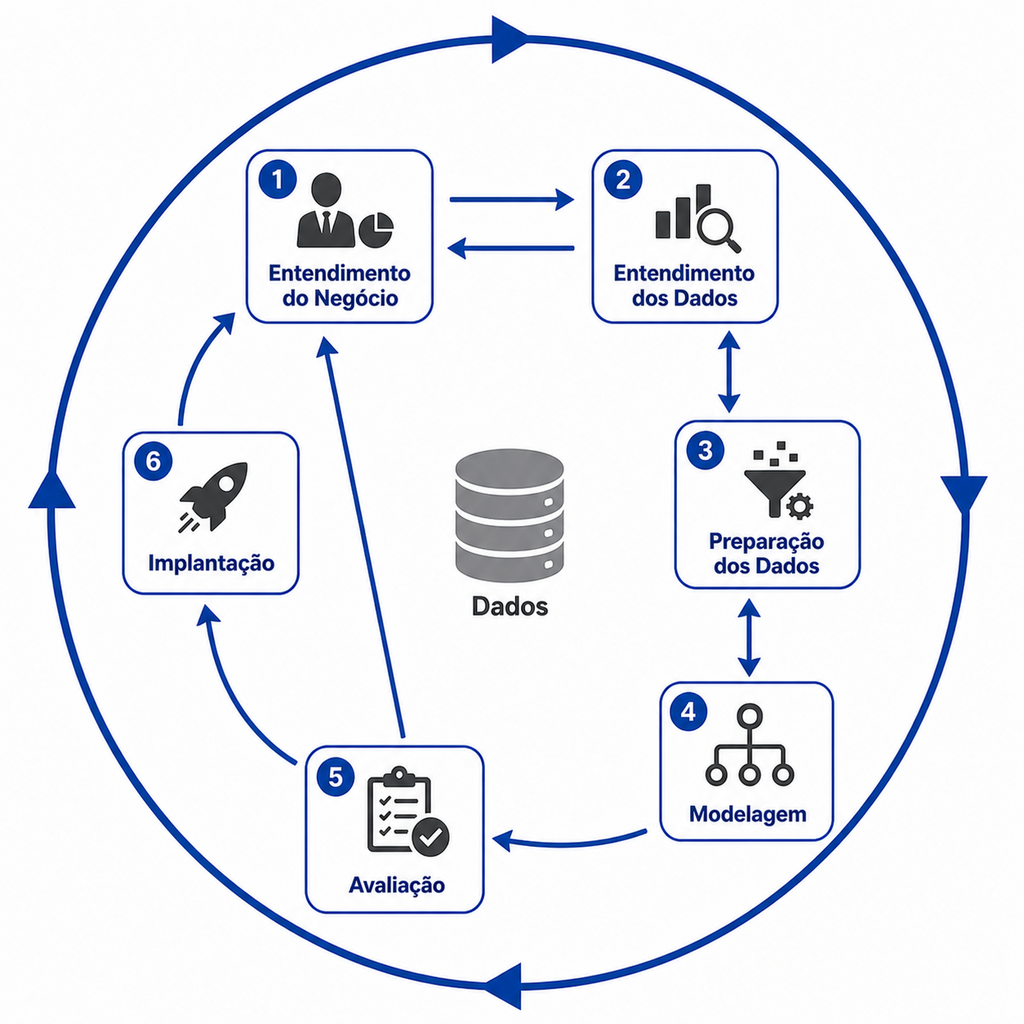

### Aplicações tradicionais de banco de dados

- Predominância de dados textuais e numéricos
- Cadastro de clientes, produtos e serviços
- Registro de transações comerciais
- Geração de relatórios operacionais

Essas aplicações formam a base dos sistemas de informação em empresas e instituições.

### Aplicações modernas

- Bancos de dados multimídia: armazenamento de imagens, áudio e vídeo
- GIS (Sistemas de Informação Geográfica): mapas, dados climáticos e imagens de satélite
- Data warehousing e processamento analítico online (OLAP — On-Line Analytical Processing): análise de grandes volumes de dados para decisão

## SGBD

O SGBD (Sistema de Gerenciamento de Banco de Dados) é o programa que gerencia o Banco: cria, organiza, protege e permite consultar os dados. Os principais SGBDs do mercado são:

PostgreSQL

MySQL

SQLite

Oracle Database

SQL Server

MongoDB

Cassandra

Hive

[figure not shown]

Db2

### Como aplicações usam o SGBD

- Aplicações **acessam o banco** por meio de **consultas** e **transações**.
- Consultas **recuperam** dados; transações **leem** e **gravam** informações.
- O SGBD também oferece **proteção** contra *falhas **e controle de** segurança**.
- Como bancos de dados têm ciclo de vida longo, o SGBD precisa sustentar **manutenção e evolução contínuas**.
- É **possível criar um sistema próprio**, mas isso exige muito software complexo; por isso, na prática, usa-se SGBD de mercado.

### Sistema de banco de dados

Para completar nossas definições iniciais, chamaremos a união do banco de dados com o software de SGBD de **sistema de banco de dados**.

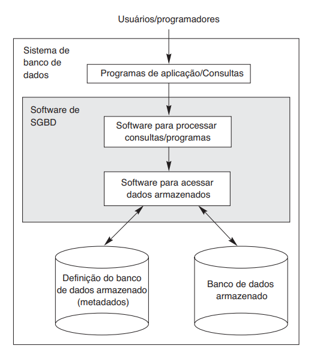

### Manipulação do banco de dados

A **manipulação** envolve duas operações principais:

- **Consulta:** recuperar informações armazenadas.
- **Atualização:** inserir, alterar ou remover dados para refletir mudanças nos dados.

As solicitações são inicialmente descritas pelo usuário e depois traduzidas para a linguagem de consulta do SGBD.

## Como faço para manipular os dados ?

**SQL** (*Structured Query Language*, ou Linguagem de Consulta Estruturada) é a linguagem padrão usada para “conversar” com o SGBD: criar, consultar e alterar os dados organizados em bancos de dados relacionais.

```sql
SELECT nome
FROM paciente;
```

SQL “pergunta” coisas ao banco em um português quase legível.

Antes de aprender SQL, você precisa entender:

1. O que são dados
2. O que é banco de dados
3. Quem gerencia isso (SGBD)
4. Como isso se relaciona

Só depois faz sentido escrever a primeira query.

## Entidade

Entidade é um grupo de informações ligadas entre si, necessárias para o funcionamento do sistema. Normalmente representa algo do mundo real.

No banco de dados, cada entidade vira uma tabela.

Uma entidade tem várias ocorrências: a entidade é “paciente” e a Maria é uma ocorrência dela.

EXEMPLO DE ENTIDADE: PACIENTE

| id_paciente | nome | idade | cidade |
| --- | --- | --- | --- |
| 1 | Maria | 39 | Fortaleza |
| 2 | João | 52 | Recife |
| 3 | Ana | 27 | Natal |

## Exemplos e Tipos de Entidade

| Categoria | Exemplos |
| --- | --- |
| Pessoas e empresas | paciente, funcionário, cliente, fornecedor, empresa |
| Documentos | ordem de compra, pedido, nota fiscal |
| Lugares | almoxarifado, departamento |
| Materiais | produtos, peças |

As entidades se dividem em dois tipos:

Fundamental

Guarda os dados básicos do sistema (paciente, médico)

Associativa

Nasce da relação entre duas entidades fundamentais (consulta liga paciente e médico)